# Risk Factor Analysis

## Outcome Variable

**Outcome Variable:** ever_sstunted

## Predictor Variables

**Intervention Variable:** hfoodsec

**Adjustment Set:**

unadjusted

## Stratifying Variables

The analysis was stratified on these variable(s):

- agecat
- studyid
- country

## Data Summary

| agecat | studyid | country | hfoodsec | ever_sstunted | n_cell | n |
| --- | --- | --- | --- | --- | --- | --- |
| 0-24 months | GMS-Nepal | NEPAL | Food Secure | 0 | 368 | 674 |
| 0-24 months | GMS-Nepal | NEPAL | Food Secure | 1 | 111 | 674 |
| 0-24 months | GMS-Nepal | NEPAL | Mildly Food Insecure | 0 | 77 | 674 |
| 0-24 months | GMS-Nepal | NEPAL | Mildly Food Insecure | 1 | 29 | 674 |
| 0-24 months | GMS-Nepal | NEPAL | Food Insecure | 0 | 66 | 674 |
| 0-24 months | GMS-Nepal | NEPAL | Food Insecure | 1 | 23 | 674 |
| 0-24 months | MAL-ED | BANGLADESH | Food Secure | 0 | 131 | 194 |
| 0-24 months | MAL-ED | BANGLADESH | Food Secure | 1 | 30 | 194 |
| 0-24 months | MAL-ED | BANGLADESH | Mildly Food Insecure | 0 | 2 | 194 |
| 0-24 months | MAL-ED | BANGLADESH | Mildly Food Insecure | 1 | 2 | 194 |
| 0-24 months | MAL-ED | BANGLADESH | Food Insecure | 0 | 17 | 194 |
| 0-24 months | MAL-ED | BANGLADESH | Food Insecure | 1 | 12 | 194 |
| 0-24 months | MAL-ED | BRAZIL | Food Secure | 0 | 3 | 129 |
| 0-24 months | MAL-ED | BRAZIL | Food Secure | 1 | 0 | 129 |
| 0-24 months | MAL-ED | BRAZIL | Mildly Food Insecure | 0 | 9 | 129 |
| 0-24 months | MAL-ED | BRAZIL | Mildly Food Insecure | 1 | 2 | 129 |
| 0-24 months | MAL-ED | BRAZIL | Food Insecure | 0 | 104 | 129 |
| 0-24 months | MAL-ED | BRAZIL | Food Insecure | 1 | 11 | 129 |
| 0-24 months | MAL-ED | INDIA | Food Secure | 0 | 143 | 212 |
| 0-24 months | MAL-ED | INDIA | Food Secure | 1 | 47 | 212 |
| 0-24 months | MAL-ED | INDIA | Mildly Food Insecure | 0 | 4 | 212 |
| 0-24 months | MAL-ED | INDIA | Mildly Food Insecure | 1 | 1 | 212 |
| 0-24 months | MAL-ED | INDIA | Food Insecure | 0 | 13 | 212 |
| 0-24 months | MAL-ED | INDIA | Food Insecure | 1 | 4 | 212 |
| 0-24 months | MAL-ED | NEPAL | Food Secure | 0 | 86 | 128 |
| 0-24 months | MAL-ED | NEPAL | Food Secure | 1 | 8 | 128 |
| 0-24 months | MAL-ED | NEPAL | Mildly Food Insecure | 0 | 15 | 128 |
| 0-24 months | MAL-ED | NEPAL | Mildly Food Insecure | 1 | 0 | 128 |
| 0-24 months | MAL-ED | NEPAL | Food Insecure | 0 | 13 | 128 |
| 0-24 months | MAL-ED | NEPAL | Food Insecure | 1 | 6 | 128 |

[output cut: 78 more lines]

The following strata were considered:

- agecat: 0-24 months, studyid: GMS-Nepal, country: NEPAL
- agecat: 0-24 months, studyid: MAL-ED, country: BANGLADESH
- agecat: 0-24 months, studyid: MAL-ED, country: BRAZIL
- agecat: 0-24 months, studyid: MAL-ED, country: INDIA
- agecat: 0-24 months, studyid: MAL-ED, country: NEPAL
- agecat: 0-24 months, studyid: MAL-ED, country: PERU
- agecat: 0-24 months, studyid: MAL-ED, country: SOUTH AFRICA
- agecat: 0-24 months, studyid: NIH-Birth, country: BANGLADESH
- agecat: 0-24 months, studyid: NIH-Crypto, country: BANGLADESH
- agecat: 0-6 months, studyid: GMS-Nepal, country: NEPAL
- agecat: 0-6 months, studyid: MAL-ED, country: BANGLADESH
- agecat: 0-6 months, studyid: MAL-ED, country: BRAZIL
- agecat: 0-6 months, studyid: MAL-ED, country: INDIA
- agecat: 0-6 months, studyid: MAL-ED, country: NEPAL
- agecat: 0-6 months, studyid: MAL-ED, country: PERU
- agecat: 0-6 months, studyid: MAL-ED, country: SOUTH AFRICA
- agecat: 0-6 months, studyid: NIH-Birth, country: BANGLADESH
- agecat: 0-6 months, studyid: NIH-Crypto, country: BANGLADESH

### Dropped Strata

Some strata were dropped due to rare outcomes:

- agecat: 0-24 months, studyid: MAL-ED, country: BANGLADESH
- agecat: 0-24 months, studyid: MAL-ED, country: BRAZIL
- agecat: 0-24 months, studyid: MAL-ED, country: INDIA
- agecat: 0-24 months, studyid: MAL-ED, country: NEPAL
- agecat: 0-6 months, studyid: MAL-ED, country: BANGLADESH
- agecat: 0-6 months, studyid: MAL-ED, country: BRAZIL
- agecat: 0-6 months, studyid: MAL-ED, country: INDIA
- agecat: 0-6 months, studyid: MAL-ED, country: NEPAL
- agecat: 0-6 months, studyid: MAL-ED, country: PERU
- agecat: 0-6 months, studyid: MAL-ED, country: SOUTH AFRICA

## Methods Detail

We’re interested in the causal parameters $E[Y_a]$ for all values of $a \in \mathcal{A}$. These parameters represent the mean outcome if, possibly contrary to fact, we intervened to set all units to have $A=a$. Under the randomization and positivity assumptions, these are identified by the statistical parameters $\psi_a=E_W[E_{Y|A,W}(Y|A=a,W)]$. In addition, we’re interested in the mean of $Y$, $E[Y]$ under no intervention (the observed mean). We will estimate these parameters by using SuperLearner to fit the relevant likelihood factors – $E_{Y|A,W}(Y|A=a,W)$ and $p(A=a|W)$, and then updating our likelihood fit using a joint TMLE.

For unadjusted analyses ($W=\{\}$), initial likelihoods were estimated using Lrnr_glm to estimate the simple $E(Y|A)$ and Lrnr_mean to estimate $p(A)$. For adjusted analyses, a small library containing Lrnr_glmnet, Lrnr_xgboost, and Lrnr_mean was used.

Having estimated these parameters, we will then use the delta method to estimate relative risks and attributable risks relative to a prespecified baseline level of $A$.

# Results Detail

## Results Plots

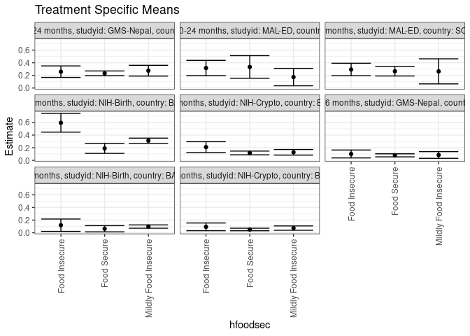

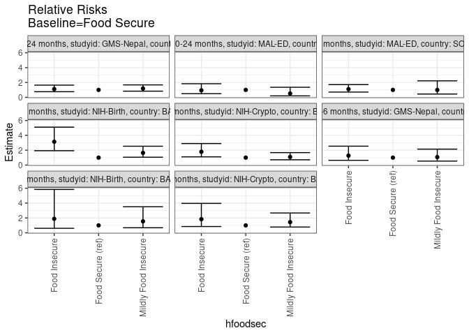

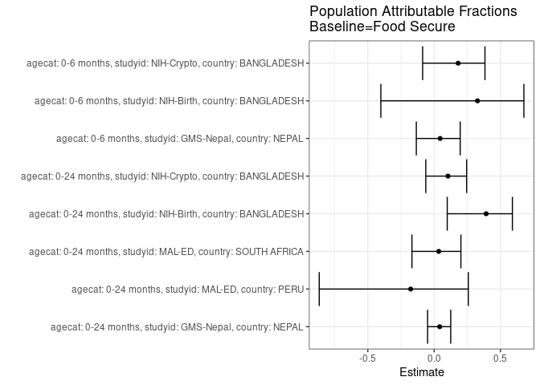

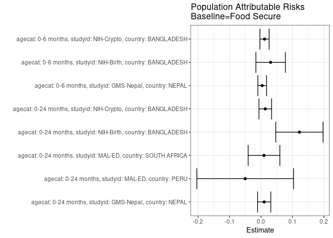

## Results Table

### Parameter: TSM

| agecat | studyid | country | intervention_level | baseline_level | estimate | ci_lower | ci_upper |
| --- | --- | --- | --- | --- | --- | --- | --- |
| 0-24 months | GMS-Nepal | NEPAL | Food Secure | NA | 0.2317328 | 0.1939188 | 0.2695468 |
| 0-24 months | GMS-Nepal | NEPAL | Mildly Food Insecure | NA | 0.2735849 | 0.1886559 | 0.3585139 |
| 0-24 months | GMS-Nepal | NEPAL | Food Insecure | NA | 0.2584270 | 0.1674102 | 0.3494437 |
| 0-24 months | MAL-ED | PERU | Food Secure | NA | 0.3333333 | 0.1547298 | 0.5119369 |
| 0-24 months | MAL-ED | PERU | Mildly Food Insecure | NA | 0.1724138 | 0.0343207 | 0.3105069 |
| 0-24 months | MAL-ED | PERU | Food Insecure | NA | 0.3157895 | 0.1945806 | 0.4369984 |
| 0-24 months | MAL-ED | SOUTH AFRICA | Food Secure | NA | 0.2651515 | 0.1896873 | 0.3406157 |
| 0-24 months | MAL-ED | SOUTH AFRICA | Mildly Food Insecure | NA | 0.2631579 | 0.0647309 | 0.4615849 |
| 0-24 months | MAL-ED | SOUTH AFRICA | Food Insecure | NA | 0.2926829 | 0.1939912 | 0.3913747 |
| 0-24 months | NIH-Birth | BANGLADESH | Food Secure | NA | 0.1894737 | 0.1106077 | 0.2683397 |
| 0-24 months | NIH-Birth | BANGLADESH | Mildly Food Insecure | NA | 0.3109756 | 0.2700409 | 0.3519103 |
| 0-24 months | NIH-Birth | BANGLADESH | Food Insecure | NA | 0.5952381 | 0.4466739 | 0.7438023 |
| 0-24 months | NIH-Crypto | BANGLADESH | Food Secure | NA | 0.1169978 | 0.0873798 | 0.1466158 |
| 0-24 months | NIH-Crypto | BANGLADESH | Mildly Food Insecure | NA | 0.1278539 | 0.0835987 | 0.1721091 |
| 0-24 months | NIH-Crypto | BANGLADESH | Food Insecure | NA | 0.2093023 | 0.1232668 | 0.2953378 |
| 0-6 months | GMS-Nepal | NEPAL | Food Secure | NA | 0.0793319 | 0.0551117 | 0.1035522 |
| 0-6 months | GMS-Nepal | NEPAL | Mildly Food Insecure | NA | 0.0849057 | 0.0318027 | 0.1380086 |
| 0-6 months | GMS-Nepal | NEPAL | Food Insecure | NA | 0.1011236 | 0.0384403 | 0.1638069 |
| 0-6 months | NIH-Birth | BANGLADESH | Food Secure | NA | 0.0631579 | 0.0142050 | 0.1121108 |
| 0-6 months | NIH-Birth | BANGLADESH | Mildly Food Insecure | NA | 0.0975610 | 0.0713213 | 0.1238006 |
| 0-6 months | NIH-Birth | BANGLADESH | Food Insecure | NA | 0.1190476 | 0.0210297 | 0.2170655 |
| 0-6 months | NIH-Crypto | BANGLADESH | Food Secure | NA | 0.0507726 | 0.0305431 | 0.0710021 |
| 0-6 months | NIH-Crypto | BANGLADESH | Mildly Food Insecure | NA | 0.0730594 | 0.0385707 | 0.1075480 |
| 0-6 months | NIH-Crypto | BANGLADESH | Food Insecure | NA | 0.0930233 | 0.0315934 | 0.1544531 |

### Parameter: E(Y)

| agecat | studyid | country | intervention_level | baseline_level | estimate | ci_lower | ci_upper |
| --- | --- | --- | --- | --- | --- | --- | --- |
| 0-24 months | GMS-Nepal | NEPAL | NA | NA | 0.2418398 | 0.2094890 | 0.2741906 |
| 0-24 months | MAL-ED | PERU | NA | NA | 0.2831858 | 0.1997451 | 0.3666266 |
| 0-24 months | MAL-ED | SOUTH AFRICA | NA | NA | 0.2746781 | 0.2172425 | 0.3321138 |
| 0-24 months | NIH-Birth | BANGLADESH | NA | NA | 0.3116057 | 0.2753823 | 0.3478292 |
| 0-24 months | NIH-Crypto | BANGLADESH | NA | NA | 0.1306069 | 0.1066024 | 0.1546113 |
| 0-6 months | GMS-Nepal | NEPAL | NA | NA | 0.0830861 | 0.0622330 | 0.1039391 |
| 0-6 months | NIH-Birth | BANGLADESH | NA | NA | 0.0937997 | 0.0709973 | 0.1166021 |
| 0-6 months | NIH-Crypto | BANGLADESH | NA | NA | 0.0620053 | 0.0448256 | 0.0791849 |

### Parameter: RR

| agecat | studyid | country | intervention_level | baseline_level | estimate | ci_lower | ci_upper |
| --- | --- | --- | --- | --- | --- | --- | --- |
| 0-24 months | GMS-Nepal | NEPAL | Food Secure | Food Secure | 1.0000000 | 1.0000000 | 1.000000 |
| 0-24 months | GMS-Nepal | NEPAL | Mildly Food Insecure | Food Secure | 1.1806051 | 0.8313716 | 1.676541 |
| 0-24 months | GMS-Nepal | NEPAL | Food Insecure | Food Secure | 1.1151938 | 0.7564394 | 1.644094 |
| 0-24 months | MAL-ED | PERU | Food Secure | Food Secure | 1.0000000 | 1.0000000 | 1.000000 |
| 0-24 months | MAL-ED | PERU | Mildly Food Insecure | Food Secure | 0.5172414 | 0.1973289 | 1.355801 |
| 0-24 months | MAL-ED | PERU | Food Insecure | Food Secure | 0.9473684 | 0.4900879 | 1.831318 |
| 0-24 months | MAL-ED | SOUTH AFRICA | Food Secure | Food Secure | 1.0000000 | 1.0000000 | 1.000000 |
| 0-24 months | MAL-ED | SOUTH AFRICA | Mildly Food Insecure | Food Secure | 0.9924812 | 0.4433061 | 2.221984 |
| 0-24 months | MAL-ED | SOUTH AFRICA | Food Insecure | Food Secure | 1.1038328 | 0.7100190 | 1.716076 |
| 0-24 months | NIH-Birth | BANGLADESH | Food Secure | Food Secure | 1.0000000 | 1.0000000 | 1.000000 |
| 0-24 months | NIH-Birth | BANGLADESH | Mildly Food Insecure | Food Secure | 1.6412602 | 1.0606786 | 2.539634 |
| 0-24 months | NIH-Birth | BANGLADESH | Food Insecure | Food Secure | 3.1415344 | 1.9335912 | 5.104098 |
| 0-24 months | NIH-Crypto | BANGLADESH | Food Secure | Food Secure | 1.0000000 | 1.0000000 | 1.000000 |
| 0-24 months | NIH-Crypto | BANGLADESH | Mildly Food Insecure | Food Secure | 1.0927888 | 0.7116998 | 1.677937 |
| 0-24 months | NIH-Crypto | BANGLADESH | Food Insecure | Food Secure | 1.7889425 | 1.1039205 | 2.899045 |
| 0-6 months | GMS-Nepal | NEPAL | Food Secure | Food Secure | 1.0000000 | 1.0000000 | 1.000000 |
| 0-6 months | GMS-Nepal | NEPAL | Mildly Food Insecure | Food Secure | 1.0702582 | 0.5336190 | 2.146574 |
| 0-6 months | GMS-Nepal | NEPAL | Food Insecure | Food Secure | 1.2746895 | 0.6387309 | 2.543846 |
| 0-6 months | NIH-Birth | BANGLADESH | Food Secure | Food Secure | 1.0000000 | 1.0000000 | 1.000000 |
| 0-6 months | NIH-Birth | BANGLADESH | Mildly Food Insecure | Food Secure | 1.5447154 | 0.6800516 | 3.508772 |
| 0-6 months | NIH-Birth | BANGLADESH | Food Insecure | Food Secure | 1.8849206 | 0.6084161 | 5.839632 |
| 0-6 months | NIH-Crypto | BANGLADESH | Food Secure | Food Secure | 1.0000000 | 1.0000000 | 1.000000 |
| 0-6 months | NIH-Crypto | BANGLADESH | Mildly Food Insecure | Food Secure | 1.4389518 | 0.7758332 | 2.668850 |
| 0-6 months | NIH-Crypto | BANGLADESH | Food Insecure | Food Secure | 1.8321537 | 0.8472446 | 3.962005 |

### Parameter: PAR

| agecat | studyid | country | intervention_level | baseline_level | estimate | ci_lower | ci_upper |
| --- | --- | --- | --- | --- | --- | --- | --- |
| 0-24 months | GMS-Nepal | NEPAL | Food Secure | NA | 0.0101070 | -0.0109659 | 0.0311798 |
| 0-24 months | MAL-ED | PERU | Food Secure | NA | -0.0501475 | -0.2038280 | 0.1035331 |
| 0-24 months | MAL-ED | SOUTH AFRICA | Food Secure | NA | 0.0095266 | -0.0408834 | 0.0599366 |
| 0-24 months | NIH-Birth | BANGLADESH | Food Secure | NA | 0.1221320 | 0.0469444 | 0.1973196 |
| 0-24 months | NIH-Crypto | BANGLADESH | Food Secure | NA | 0.0136091 | -0.0065139 | 0.0337320 |
| 0-6 months | GMS-Nepal | NEPAL | Food Secure | NA | 0.0037541 | -0.0099451 | 0.0174533 |
| 0-6 months | NIH-Birth | BANGLADESH | Food Secure | NA | 0.0306418 | -0.0161820 | 0.0774656 |
| 0-6 months | NIH-Crypto | BANGLADESH | Food Secure | NA | 0.0112327 | -0.0034383 | 0.0259036 |

### Parameter: PAF

| agecat | studyid | country | intervention_level | baseline_level | estimate | ci_lower | ci_upper |
| --- | --- | --- | --- | --- | --- | --- | --- |
| 0-24 months | GMS-Nepal | NEPAL | Food Secure | NA | 0.0417921 | -0.0493518 | 0.1250195 |
| 0-24 months | MAL-ED | PERU | Food Secure | NA | -0.1770833 | -0.8662521 | 0.2575895 |
| 0-24 months | MAL-ED | SOUTH AFRICA | Food Secure | NA | 0.0346828 | -0.1674004 | 0.2017843 |
| 0-24 months | NIH-Birth | BANGLADESH | Food Secure | NA | 0.3919441 | 0.0986469 | 0.5898035 |
| 0-24 months | NIH-Crypto | BANGLADESH | Food Secure | NA | 0.1041987 | -0.0628818 | 0.2450149 |
| 0-6 months | GMS-Nepal | NEPAL | Food Secure | NA | 0.0451834 | -0.1344042 | 0.1963405 |
| 0-6 months | NIH-Birth | BANGLADESH | Food Secure | NA | 0.3266726 | -0.4017699 | 0.6765733 |
| 0-6 months | NIH-Crypto | BANGLADESH | Food Secure | NA | 0.1811564 | -0.0867976 | 0.3830453 |